# Modeling Engel outcomes (Multiclass) using clinical data

## One-hot encoding

One-hot encode the new columns from Epliepsy diagnosis information

```python
# One-Hot Encoding for the first four columns
X = pd.get_dummies(
    X,
    columns=[
        "surg_stage",
        "seiz_onset_lat"
        #"Cleaned_Surgeon"
    ],
)  # , "prev_aeds"
```

## Correlation matrix

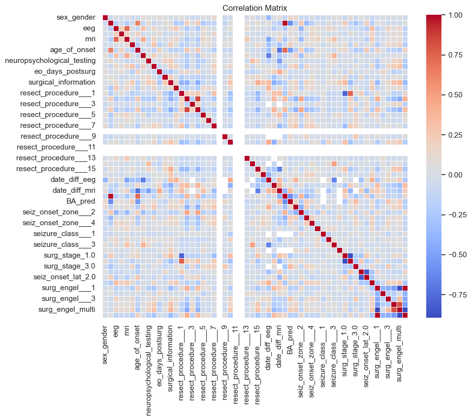

```python
import pandas as pd
import seaborn as sns
import matplotlib.pyplot as plt

engel = wide_df[
    [
        "surg_engel___1",
        "surg_engel___2",
        "surg_engel___3",
        "surg_engel___4",
        "surg_engel",
    ]
]
engel = engel.rename(columns={"surg_engel": "surg_engel_multi"})
y2 = y == 0
engel = pd.concat([engel, y2], axis=1)

# Calculate the correlation matrix
correlation_matrix = pd.concat([X.drop("epi_dx", axis=1), engel], axis=1).corr()

# Create a heatmap using seaborn
sns.set(style="white")
plt.figure(figsize=(10, 8))
sns.heatmap(correlation_matrix, annot=False, cmap="coolwarm", fmt=".2f", linewidths=0.5)
plt.title("Correlation Matrix")
plt.show()
```

### Check for high correlation variables

```python
# Set a threshold for high correlation (e.g., 0.8 for 80%)
threshold = 0.8

# Find pairs of variables with a very high correlation
high_correlation_pairs = []
for i in range(len(correlation_matrix.columns)):
    for j in range(i + 1, len(correlation_matrix.columns)):
        if abs(correlation_matrix.iloc[i, j]) > threshold:
            high_correlation_pairs.append(
                (correlation_matrix.columns[i], correlation_matrix.columns[j])
            )

# Print the pairs of variables with a very high correlation
print(f"Pairs of variables with correlation above {threshold}:")
for pair in high_correlation_pairs:
    print(pair)

del correlation_matrix, threshold, high_correlation_pairs, pair, i, j
```

```
Pairs of variables with correlation above 0.8:
('resect_pt_age', 'presurg_scan_age')
('resect_procedure___2', 'resect_procedure___4')
('surg_stage_1.0', 'surg_stage_2.0')
('seiz_onset_lat_1.0', 'seiz_onset_lat_2.0')
('surg_engel___1', 'surg_engel_multi')
('surg_engel___1', 'surg_engel')
('surg_engel___4', 'surg_engel_multi')
('surg_engel_multi', 'surg_engel')
```

## Split data into train/test

```python
from sklearn.model_selection import train_test_split
X_train, X_test, y_train, y_test = train_test_split(
    X, y, stratify=y, test_size=0.2, random_state=42
)
```

## Term frequency analysis

```python
import numpy as np
import pandas as pd
from sklearn.feature_extraction.text import CountVectorizer
from scipy.stats import entropy

# Create and fit a CountVectorizer
count_vectorizer = CountVectorizer(
    binary=True, ngram_range=(1, 3)
)  # binary=True will set all non-zero counts to 1
count_vectorizer.fit(X_train["epi_dx"])

# Transform the training and test data
X_train_count = count_vectorizer.transform(X_train["epi_dx"])
X_test_count = count_vectorizer.transform(X_test["epi_dx"])

# Convert to DataFrame
X_train_count_df = pd.DataFrame(
    X_train_count.toarray(), columns=count_vectorizer.get_feature_names_out()
)
X_test_count_df = pd.DataFrame(
    X_test_count.toarray(), columns=count_vectorizer.get_feature_names_out()
)

# Calculate probabilities for the presence (1) and absence (0) of each term
probabilities = X_train_count_df.apply(
    lambda x: [np.mean(x), 1 - np.mean(x)], result_type="expand"
)

# Calculate Shannon entropy using scipy.stats.entropy
entropies_scipy = probabilities.apply(lambda x: entropy(x, base=2), axis=0)

# Sort features by their entropy
entropies_sorted_scipy = entropies_scipy.sort_values()

del count_vectorizer
```

```python
#X_train_count_df["amtl"].sum()
```

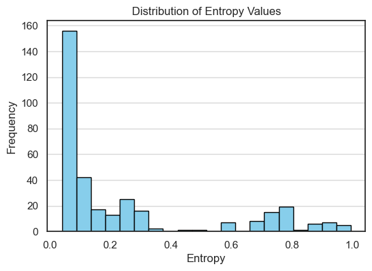

```python
import matplotlib.pyplot as plt

# Plot the distribution of entropy values
plt.figure(figsize=(6, 4))
plt.hist(entropies_sorted_scipy, bins=20, color="skyblue", edgecolor="black")
plt.title("Distribution of Entropy Values")
plt.xlabel("Entropy")
plt.ylabel("Frequency")
plt.grid(axis="y", alpha=0.75)

plt.show()
```

```python
# Filter Entropies to get a range of useful values
filtered_entropies_sorted = entropies_sorted_scipy[
    (entropies_sorted_scipy > 0.3) & (entropies_sorted_scipy < 0.7)
]

# Filtered columns based on entropy thresholds
filtered_columns = filtered_entropies_sorted.index.tolist()

# Select columns from the DataFrames based on filtered features by entropy
X_train_filtered = X_train_count_df[filtered_columns]
X_test_filtered = X_test_count_df[filtered_columns]

# Remove the 'epi_dx' column from X_train and X_test
X_train = X_train.drop("epi_dx", axis=1)
X_test = X_test.drop("epi_dx", axis=1)

# Filter out the features that have the same name as columns in X_train and X_test to avoid duplication
common_columns = set(X_train.columns) & set(X_train_filtered.columns)
X_train_filtered_unique = X_train_filtered.drop(columns=common_columns)
X_test_filtered_unique = X_test_filtered.drop(columns=common_columns)

# Concatenate the filtered features with the modified X_train and X_test
X_train = pd.concat(
    [X_train.reset_index(drop=True), X_train_filtered_unique.reset_index(drop=True)],
    axis=1,
)
X_test = pd.concat(
    [X_test.reset_index(drop=True), X_test_filtered_unique.reset_index(drop=True)],
    axis=1,
)

del (
    common_columns,
    X_train_filtered_unique,
    X_test_filtered_unique,
    X_train_filtered,
    X_test_filtered,
    filtered_columns,
    filtered_entropies_sorted,
)
```

## 10-fold cross-validation

By splitting your data into multiple training and validation sets (like in k-fold cross-validation), you can assess the consistency of your model’s performance. Fluctuations in performance across different folds can indicate overfitting, while uniformly poor performance across folds suggests underfitting.

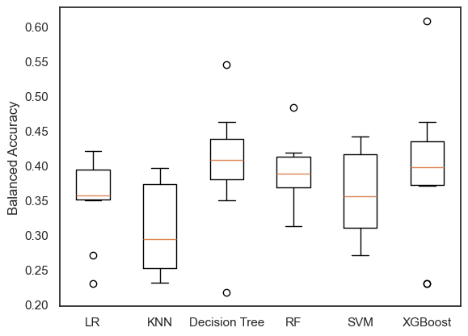

```python
import matplotlib.pyplot as plt
from sklearn.model_selection import cross_val_score, StratifiedKFold
from sklearn.neighbors import KNeighborsClassifier
from sklearn.linear_model import LogisticRegression
from sklearn.tree import DecisionTreeClassifier
from sklearn.ensemble import RandomForestClassifier
from sklearn.svm import SVC
from xgboost import XGBClassifier
from sklearn.compose import make_column_transformer
from sklearn.preprocessing import StandardScaler
from sklearn.impute import SimpleImputer
from sklearn.pipeline import Pipeline, make_pipeline

# List of continuous variables
numeric_var = ["resect_pt_age",
               "age_of_onset",
               "eo_days_postsurg",
               "eo_year_surg",
               "seizure_notes_word_cnt",
               "eeg",
               "engel_outcomes",
               "mri",
               "neuroanatomical_labeling",
               "neuropsychological_testing",
               "surgical_information",
               "freq_per_month",
               "date_diff_eeg",
               "date_diff_neuropsychological_testing",
               "date_diff_mri",
               "presurg_scan_age",
                "BA_pred"] # , "prev_aeds_num"

column_names = numeric_var + list(set(X_train.columns) - set(numeric_var))

# Define preprocessing pipelines
numeric_pipe = make_pipeline(SimpleImputer(strategy='median'), StandardScaler())
categorical_pipe = make_pipeline(SimpleImputer(strategy='most_frequent'))

# Define the preprocessing pipeline
preprocessor = make_column_transformer(
    (numeric_pipe, numeric_var),
    remainder=categorical_pipe
)

# Define models
models = {
    "LR": LogisticRegression(max_iter=2000, random_state=42),
    "KNN": KNeighborsClassifier(),
    "Decision Tree": DecisionTreeClassifier(random_state=42),
    "RF": RandomForestClassifier(random_state=42),
    "SVM": SVC(max_iter=2000, random_state=42),
    "XGBoost": XGBClassifier(random_state=42)
}

results = []

# Loop through models
for model_name, model in models.items():
    # Create a pipeline with the preprocessor and the model
    pipeline = Pipeline([
        ('preprocessor', preprocessor),
        ('model', model)
    ])

    # Create a stratified k-fold cross-validator
    kf = StratifiedKFold(n_splits=10, random_state=42, shuffle=True)

    # Cross-validate using the pipeline
    cv_results = cross_val_score(pipeline, X_train, y_train, cv=kf, scoring='balanced_accuracy')

    # Append cross-validation results to the results list
    results.append(cv_results)

# Plot the results
plt.boxplot(results, labels=models.keys())

plt.ylabel('Balanced Accuracy')
plt.show()
```

```python
import numpy as np
import pandas as pd
from sklearn.compose import make_column_transformer
from sklearn.pipeline import make_pipeline
from sklearn.impute import SimpleImputer
from sklearn.preprocessing import StandardScaler
from sklearn.ensemble import RandomForestClassifier
from sklearn.metrics import roc_auc_score
from sklearn.model_selection import GridSearchCV, StratifiedKFold
from sklearn.base import clone

unique_classes = np.unique(y_train)

# Initialize a dictionary to hold the binary classifiers
ovr_classifiers = {}

# Define the preprocessing pipeline
preprocessor = make_column_transformer(
    (make_pipeline(SimpleImputer(strategy='median'), StandardScaler()), numeric_var),
    remainder=make_pipeline(SimpleImputer(strategy='most_frequent'))
)

# Parameter grid for GridSearchCV
param_grid = {'classifier__n_estimators': np.linspace(5, 115, 15, dtype=int),
              'classifier__max_depth': np.linspace(2, 5, 4, dtype=int)}

# Loop over each class and create a binary classifier for each
for cls in unique_classes:
    # Create a binary target vector
    y_train_binary = (y_train == cls).astype(int)

    # Create a new RandomForestClassifier instance
    clf = RandomForestClassifier(random_state=42)

    # Define the pipeline with named steps
    pipeline = Pipeline([
        ('preprocessor', preprocessor),
        ('classifier', RandomForestClassifier(random_state=42))
    ])

    # Setup GridSearchCV
    clf_cv = GridSearchCV(pipeline, param_grid,
                          cv=StratifiedKFold(n_splits=10, random_state=42, shuffle=True),
                          scoring="balanced_accuracy",
                          n_jobs=-1)

    # Fit the model
    clf_cv.fit(X_train, y_train_binary)

    # Store the fitted model
    ovr_classifiers[cls] = clf_cv

# To predict, aggregate predictions from all OvR classifiers
def predict_ovr(classifiers, X):
    # Get probabilities for each class being the positive class
    probas = np.array([clf.predict_proba(X)[:, 1] for clf in classifiers.values()]).T

    # Predict the class with the highest probability
    return np.argmax(probas, axis=1)

# Predict on the test set
y_train_pred = predict_ovr(ovr_classifiers, X_train)
y_test_pred = predict_ovr(ovr_classifiers, X_test)

# Adjust predict_ovr to return probabilities instead of class predictions
def predict_ovr_probas(classifiers, X):
    # Get probabilities for each class being the positive class
    probas = np.array([clf.best_estimator_.predict_proba(X)[:, 1] for clf in classifiers.values()]).T
    return probas

# Use the adjusted function to get probabilities for the training and test sets
y_train_pred_probas = predict_ovr_probas(ovr_classifiers, X_train)
y_test_pred_probas = predict_ovr_probas(ovr_classifiers, X_test)
```

```python
# Function to compute AUC for each class individually and return the average AUC
def compute_individual_auc(classifiers, X, y_true):
    auc_scores = []
    for cls, clf in classifiers.items():
        # Predict the probability of the positive class
        y_pred_proba = clf.best_estimator_.predict_proba(X)[:, 1]
        # Binarize the true labels for the current class
        y_true_binary = (y_true == cls).astype(int)
        # Compute the AUC score for the current class
        auc_score = roc_auc_score(y_true_binary, y_pred_proba)
        auc_scores.append(auc_score)
        print(f"Class {cls} AUC: {auc_score}")
    # Return the average AUC score
    return np.mean(auc_scores)

# Compute and print the average AUC score for the training set
average_train_auc = compute_individual_auc(ovr_classifiers, X_train, y_train)
print(f"Average Training AUC (One-vs-Rest): {average_train_auc}")

# Compute and print the average AUC score for the test set
average_test_auc = compute_individual_auc(ovr_classifiers, X_test, y_test)
print(f"Average Test AUC (One-vs-Rest): {average_test_auc}")
```

```
Class 0 AUC: 0.8950189859280768
Class 1 AUC: 0.7429081025989468
Class 2 AUC: 0.9785997732426304
Class 3 AUC: 0.9444834034595605
Average Training AUC (One-vs-Rest): 0.8902525663073036
Class 0 AUC: 0.6845238095238095
Class 1 AUC: 0.3179271708683473
Class 2 AUC: 0.764172335600907
Class 3 AUC: 0.644927536231884
Average Test AUC (One-vs-Rest): 0.6028877130562369
```

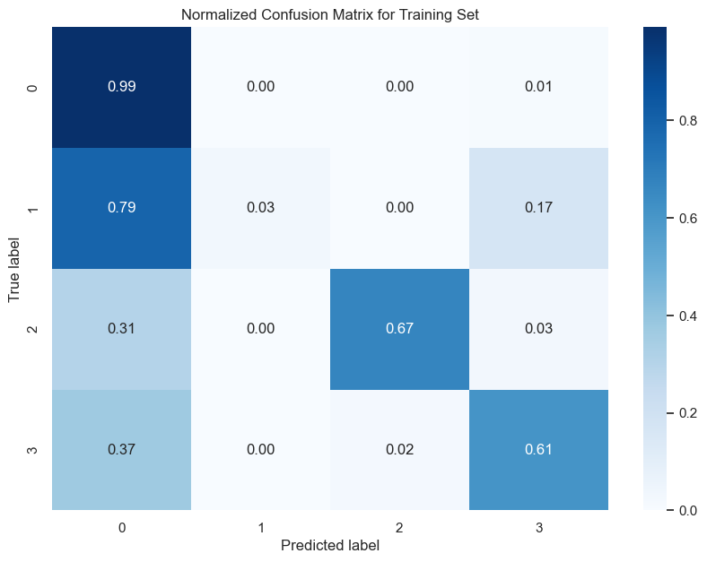

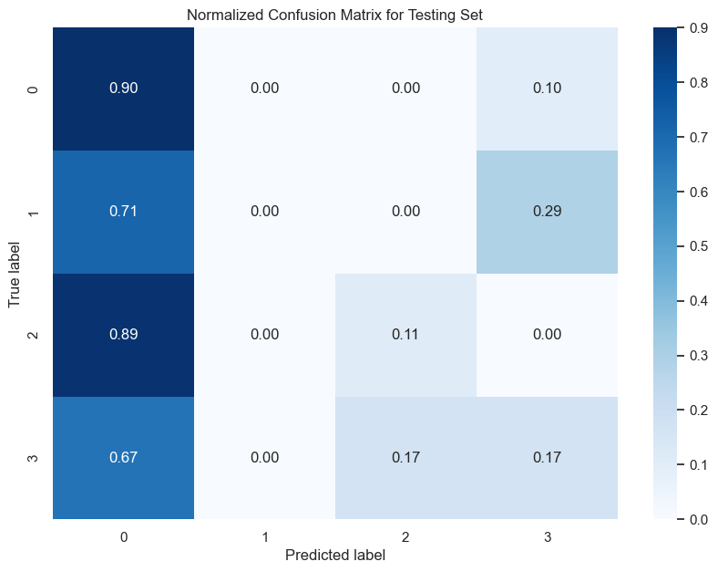

```python
from sklearn.metrics import confusion_matrix
import matplotlib.pyplot as plt
import seaborn as sns

# Adjust predict_ovr to match unique_classes
def predict_ovr_adjusted(classifiers, X, unique_classes):
    probas = np.array([clf.predict_proba(X)[:, 1] for clf in classifiers.values()]).T
    return unique_classes[np.argmax(probas, axis=1)]

# Predict on the training and test set using the adjusted function
y_train_pred_adjusted = predict_ovr_adjusted(ovr_classifiers, X_train, unique_classes)
y_test_pred_adjusted = predict_ovr_adjusted(ovr_classifiers, X_test, unique_classes)

# Function to plot confusion matrix
def plot_confusion_matrix(y_true, y_pred, classes, set_name):
    # Compute confusion matrix
    cm = confusion_matrix(y_true, y_pred, labels=classes)
    cm_normalized = cm.astype('float') / cm.sum(axis=1)[:, np.newaxis]  # Normalize

    # Plot
    plt.figure(figsize=(10, 7))
    sns.heatmap(cm_normalized, annot=True, fmt=".2f", cmap="Blues", xticklabels=classes, yticklabels=classes)
    plt.title(f'Normalized Confusion Matrix for {set_name}')
    plt.xlabel('Predicted label')
    plt.ylabel('True label')
    plt.show()

# Plot confusion matrices
plot_confusion_matrix(y_train, y_train_pred_adjusted, unique_classes, "Training Set")
plot_confusion_matrix(y_test, y_test_pred_adjusted, unique_classes, "Testing Set")
```

```python
import numpy as np
import pandas as pd
from sklearn.compose import make_column_transformer
#from sklearn.pipeline import Pipeline  # Ensure you're using Pipeline from sklearn, not make_pipeline for compatibility with SMOTE
from sklearn.impute import SimpleImputer
from sklearn.preprocessing import StandardScaler
from sklearn.ensemble import RandomForestClassifier
from sklearn.metrics import roc_auc_score
from sklearn.model_selection import GridSearchCV, StratifiedKFold
from sklearn.base import clone
from imblearn.over_sampling import SMOTE
from imblearn.pipeline import make_pipeline as make_pipeline_imblearn  # Use imblearn's make_pipeline for compatibility with SMOTE
from imblearn.pipeline import Pipeline as ImblearnPipeline  # Use ImblearnPipeline to allow for SMOTE


unique_classes = np.unique(y_train)

# Initialize a dictionary to hold the binary classifiers
ovr_classifiers = {}

# Define the preprocessing pipeline
preprocessor = make_column_transformer(
    (make_pipeline(SimpleImputer(strategy='median'), StandardScaler()), numeric_var),
    remainder=make_pipeline(SimpleImputer(strategy='most_frequent'))
)

# Parameter grid for GridSearchCV
param_grid = {'classifier__n_estimators': np.linspace(5, 115, 15, dtype=int),
              'classifier__max_depth': np.linspace(2, 5, 4, dtype=int)}

# Loop over each class and create a binary classifier for each
for cls in unique_classes:
    # Create a binary target vector
    y_train_binary = (y_train == cls).astype(int)

    # Define the pipeline with named steps, including SMOTE
    pipeline = ImblearnPipeline([
        ('preprocessor', preprocessor),
        ('smote', SMOTE(random_state=42)),
        ('classifier', RandomForestClassifier(random_state=42))
    ])

    # Setup GridSearchCV
    clf_cv = GridSearchCV(pipeline, param_grid,
                          cv=StratifiedKFold(n_splits=10, random_state=42, shuffle=True),
                          scoring="balanced_accuracy",
                          n_jobs=-1)

    # Fit the model
    clf_cv.fit(X_train, y_train_binary)

    # Store the fitted model
    ovr_classifiers[cls] = clf_cv

# To predict, aggregate predictions from all OvR classifiers
def predict_ovr(classifiers, X):
    # Get probabilities for each class being the positive class
    probas = np.array([clf.predict_proba(X)[:, 1] for clf in classifiers.values()]).T

    # Predict the class with the highest probability
    return np.argmax(probas, axis=1)

# Predict on the test set
y_train_pred = predict_ovr(ovr_classifiers, X_train)
y_test_pred = predict_ovr(ovr_classifiers, X_test)

# Adjust predict_ovr to return probabilities instead of class predictions
def predict_ovr_probas(classifiers, X):
    # Get probabilities for each class being the positive class
    probas = np.array([clf.best_estimator_.predict_proba(X)[:, 1] for clf in classifiers.values()]).T
    return probas

# Use the adjusted function to get probabilities for the training and test sets
y_train_pred_probas = predict_ovr_probas(ovr_classifiers, X_train)
y_test_pred_probas = predict_ovr_probas(ovr_classifiers, X_test)

# Compute and print the average AUC score for the training set
average_train_auc = compute_individual_auc(ovr_classifiers, X_train, y_train)
print(f"Average Training AUC (One-vs-Rest): {average_train_auc}")

# Compute and print the average AUC score for the test set
average_test_auc = compute_individual_auc(ovr_classifiers, X_test, y_test)
print(f"Average Test AUC (One-vs-Rest): {average_test_auc}")
```

```
Class 0 AUC: 0.9678356041992405
Class 1 AUC: 0.9792763716663835
Class 2 AUC: 0.8684807256235828
Class 3 AUC: 0.8674614305750351
Average Training AUC (One-vs-Rest): 0.9207635330160605
Class 0 AUC: 0.7
Class 1 AUC: 0.5770308123249299
Class 2 AUC: 0.5396825396825398
Class 3 AUC: 0.6376811594202899
Average Test AUC (One-vs-Rest): 0.6135986278569399
```

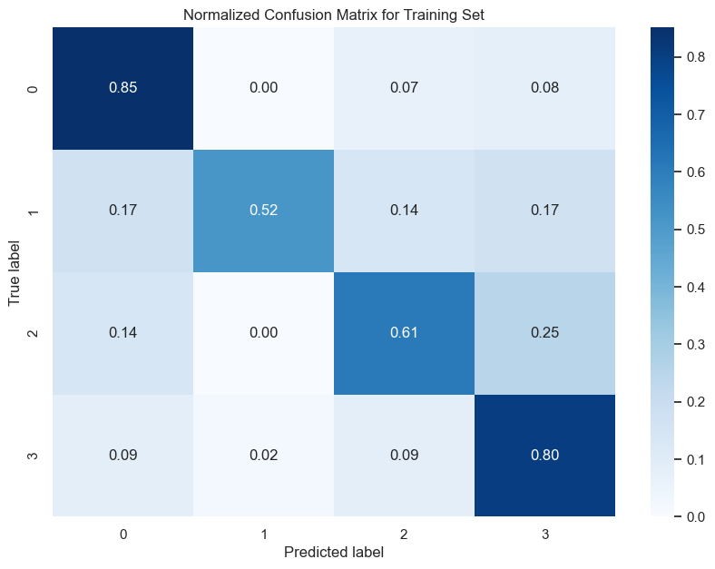

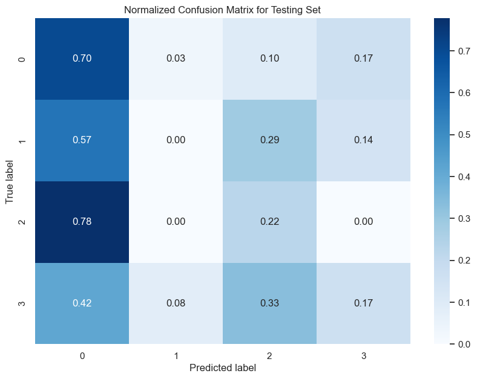

```python
# Predict on the training and test set using the adjusted function
y_train_pred_adjusted = predict_ovr_adjusted(ovr_classifiers, X_train, unique_classes)
y_test_pred_adjusted = predict_ovr_adjusted(ovr_classifiers, X_test, unique_classes)

# Plot confusion matrices
plot_confusion_matrix(y_train, y_train_pred_adjusted, unique_classes, "Training Set")
plot_confusion_matrix(y_test, y_test_pred_adjusted, unique_classes, "Testing Set")
```

```
Final Model AUC: 0.9757799794292664
Final Model AUC: 0.6204748384861191
```

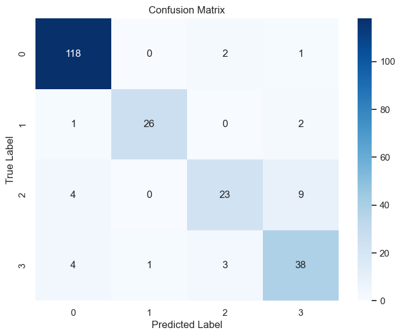

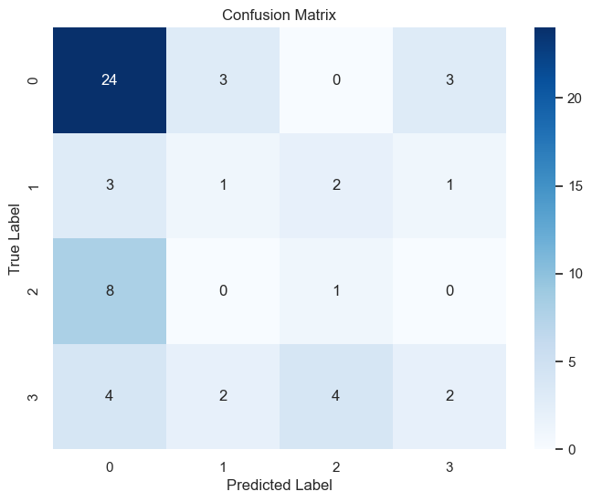

```python
from sklearn.ensemble import RandomForestClassifier
from sklearn.metrics import accuracy_score
from sklearn.linear_model import LogisticRegressionCV

# Initialize the final model
final_model2 = LogisticRegressionCV(l1_ratios=np.linspace(0, 1, 10),
                                  penalty='elasticnet',
                                  solver='saga',
                                  cv=StratifiedKFold(n_splits=10, random_state=42, shuffle=True),
                                  multi_class='ovr',
                                  scoring="roc_auc",
                                  random_state=42,
                                  max_iter=10000,
                                  n_jobs=-1)

final_model = RandomForestClassifier(max_depth=3, random_state=42)

# Train the final model on the output of the OvR classifiers
final_model.fit(y_train_pred_probas, y_train)

# Predict on the new test set
final_predictions_test = final_model.predict(y_test_pred_probas)
final_predictions_train = final_model.predict(y_train_pred_probas)

y_test_pred_probas_final = final_model.predict_proba(y_test_pred_probas)
y_train_pred_probas_final = final_model.predict_proba(y_train_pred_probas)

final_train_auc = roc_auc_score(y_train, y_train_pred_probas_final, multi_class="ovr")
print(f"Final Model AUC: {final_train_auc}")

final_test_auc = roc_auc_score(y_test, y_test_pred_probas_final, multi_class="ovr")
print(f"Final Model AUC: {final_test_auc}")

# Generate the confusion matrix
cm = confusion_matrix(y_train, final_predictions_train)
cm2 = confusion_matrix(y_test, final_predictions_test)

# Function to plot the confusion matrix
def plot_confusion_matrix(cm, classes):
    plt.figure(figsize=(8, 6))
    sns.heatmap(cm, annot=True, fmt="d", cmap="Blues", xticklabels=classes, yticklabels=classes)
    plt.title('Confusion Matrix')
    plt.ylabel('True Label')
    plt.xlabel('Predicted Label')
    plt.show()

plot_confusion_matrix(cm, unique_classes)
plot_confusion_matrix(cm2, unique_classes)
```

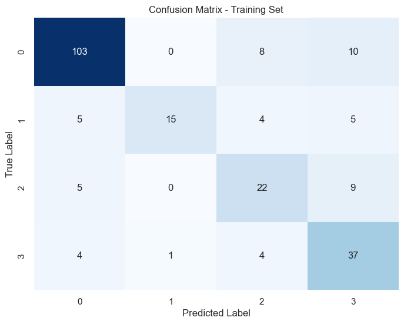

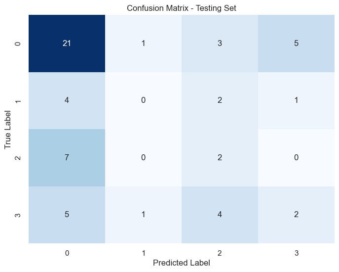

```python
from sklearn.metrics import confusion_matrix
import seaborn as sns
import matplotlib.pyplot as plt

# Assuming you have `predict_ovr` function that returns class predictions
# and it has been corrected to work with your classifiers setup
y_train_pred = predict_ovr(ovr_classifiers, X_train)
y_test_pred = predict_ovr(ovr_classifiers, X_test)

# Compute confusion matrices
conf_matrix_train = confusion_matrix(y_train, y_train_pred)
conf_matrix_test = confusion_matrix(y_test, y_test_pred)

# Function to plot confusion matrix
def plot_confusion_matrix(conf_matrix, title='Confusion Matrix'):
    plt.figure(figsize=(8, 6))
    sns.heatmap(conf_matrix, annot=True, fmt='d', cmap='Blues', cbar=False)
    plt.xlabel('Predicted Label')
    plt.ylabel('True Label')
    plt.title(title)

# Plot confusion matrix for the training set
plot_confusion_matrix(conf_matrix_train, title='Confusion Matrix - Training Set')

# Plot confusion matrix for the testing set
plot_confusion_matrix(conf_matrix_test, title='Confusion Matrix - Testing Set')
```

```python
from sklearn.metrics import classification_report

print(classification_report(y_train_pred, y_train))
```

```
              precision    recall  f1-score   support

           0       0.85      0.88      0.87       117
           1       0.52      0.94      0.67        16
           2       0.61      0.58      0.59        38
           3       0.80      0.61      0.69        61

    accuracy                           0.76       232
   macro avg       0.70      0.75      0.70       232
weighted avg       0.78      0.76      0.76       232
```

```python
from sklearn.metrics import classification_report

print(classification_report(y_test_pred, y_test))
```

```
              precision    recall  f1-score   support

           0       0.70      0.57      0.63        37
           1       0.00      0.00      0.00         2
           2       0.22      0.18      0.20        11
           3       0.17      0.25      0.20         8

    accuracy                           0.43        58
   macro avg       0.27      0.25      0.26        58
weighted avg       0.51      0.43      0.47        58
```

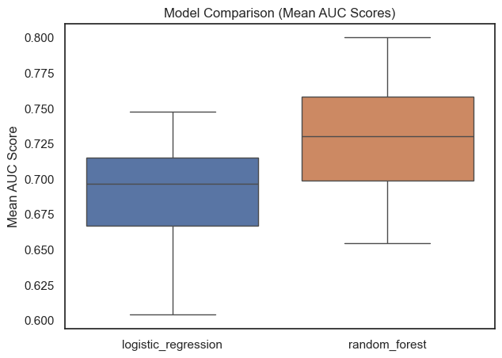

```python
import numpy as np
import pandas as pd
import matplotlib.pyplot as plt
import seaborn as sns
from sklearn.compose import make_column_transformer
from sklearn.pipeline import Pipeline
from sklearn.impute import SimpleImputer
from sklearn.preprocessing import StandardScaler
from sklearn.model_selection import GridSearchCV, StratifiedKFold
from sklearn.linear_model import LogisticRegression
from sklearn.ensemble import RandomForestClassifier
from sklearn.metrics import roc_auc_score
from sklearn.utils import class_weight
from xgboost import XGBClassifier
from sklearn.multiclass import OneVsRestClassifier
from sklearn.metrics import roc_curve, auc
from sklearn.preprocessing import label_binarize
from sklearn.metrics import roc_curve, auc

X_CV = X_train
y_CV = y_train

# List of continuous variables
numeric_var = [
    "resect_pt_age", #age
    "age_of_onset",
    "eo_days_postsurg",
    "eo_year_surg",
    "seizure_notes_word_cnt",
    "eeg",
    "engel_outcomes",
    "mri",
    "neuroanatomical_labeling",
    "neuropsychological_testing",
    "surgical_information",
    "freq_per_month",
    "date_diff_eeg",
    "date_diff_neuropsychological_testing",
    "date_diff_mri",
    "presurg_scan_age",
    "BA_pred"
]  # , "prev_aeds_num"


# Define preprocessing pipelines
numeric_pipe = make_pipeline(SimpleImputer(strategy='median'), StandardScaler())
categorical_pipe = make_pipeline(SimpleImputer(strategy='most_frequent'))

# Define the preprocessing pipeline
preprocessor = make_column_transformer(
    (numeric_pipe, numeric_var),
    remainder=categorical_pipe
)

# Calculate class weights
#class_weights = class_weight.compute_class_weight(class_weight='balanced', classes=np.unique(y_CV), y=y_CV)
#class_weights_dict = {i: class_weights[i] for i in range(len(class_weights))}

# Define model pipelines with named steps
model_pipelines = {
    'logistic_regression': Pipeline([
        ('preprocessor', preprocessor),
        ('model', LogisticRegression(penalty='elasticnet', solver='saga', multi_class='ovr', max_iter=10000, random_state=42, n_jobs=-1)) #class_weight=class_weights_dict
    ]),
    'random_forest': Pipeline([
        ('preprocessor', preprocessor),
        ('model', OneVsRestClassifier(RandomForestClassifier(random_state=42), n_jobs=-1)) #class_weight=class_weights_dict
    ])
    #'xgboost': Pipeline([
    #    ('preprocessor', preprocessor),
    #    ('model', OneVsRestClassifier(XGBClassifier(use_label_encoder=False, eval_metric='mlogloss'), n_jobs=-1))
    #])
}

# Define hyperparameter grids for each model
models_and_parameters = {
    'logistic_regression': {'model__C': np.logspace(-5, -2, 4),
                            'model__l1_ratio': np.linspace(0, 1, 6)},
    'random_forest': {'model__estimator__n_estimators': np.linspace(5, 120, 5, dtype=int),
                      'model__estimator__max_depth': np.linspace(2, 5, 4, dtype=int)}
    #'xgboost': {'model__estimator__n_estimators': np.linspace(5, 120, 5, dtype=int),
    #            'model__estimator__learning_rate': np.logspace(-3, -1, 5)}
}

# Perform nested cross-validation and store AUC scores
outer_cv = StratifiedKFold(n_splits=10, random_state=42, shuffle=True)
inner_cv = StratifiedKFold(n_splits=10, random_state=42, shuffle=True)
results = {}
best_params = {}

n_classes = len(np.unique(y_CV))

for model_name, pipeline in model_pipelines.items():
    param_grid = models_and_parameters[model_name]
    mean_auc_scores = []
    params = []

    for train_idx, test_idx in outer_cv.split(X_CV, y_CV):
        X_train_fold, X_test_fold = X_CV.iloc[train_idx], X_CV.iloc[test_idx]
        y_train_fold, y_test_fold = y_CV.iloc[train_idx], y_CV.iloc[test_idx]

        # Binarize the output for multiclass ROC AUC
        y_test_fold_bin = label_binarize(y_test_fold, classes=range(n_classes))

        # Inner CV for hyperparameter tuning
        grid_search = GridSearchCV(pipeline, param_grid, cv=inner_cv, scoring='roc_auc_ovr', n_jobs=-1)
        grid_search.fit(X_train_fold, y_train_fold)

        # Best model and parameters
        best_model = grid_search.best_estimator_
        params.append(grid_search.best_params_)

        # Evaluate on test set
        y_pred_proba = best_model.predict_proba(X_test_fold)

        # Compute ROC curve and AUC for each class
        fpr = dict()
        tpr = dict()
        roc_auc = dict()
        for i in range(n_classes):
            fpr[i], tpr[i], _ = roc_curve(y_test_fold_bin[:, i], y_pred_proba[:, i])
            roc_auc[i] = auc(fpr[i], tpr[i])

        # Compute mean AUC
        mean_auc = np.mean(list(roc_auc.values()))
        mean_auc_scores.append(mean_auc)

    results[model_name] = mean_auc_scores
    best_params[model_name] = params

# Convert results to a DataFrame for easier plotting
all_scores = pd.DataFrame(results)

# Plot AUC scores
plt.figure(figsize=(7, 5))
sns.boxplot(data=all_scores)
plt.title('Model Comparison (Mean AUC Scores)')
plt.ylabel('Mean AUC Score')
plt.show()
```

```python
import numpy as np
import pandas as pd
from sklearn.compose import make_column_transformer
from sklearn.pipeline import make_pipeline
from sklearn.impute import SimpleImputer
from sklearn.preprocessing import StandardScaler
from sklearn.linear_model import LogisticRegressionCV
from sklearn.metrics import roc_auc_score, roc_curve

numeric_var = [
    "resect_pt_age", #age
    "age_of_onset",
    "eo_days_postsurg",
    "eo_year_surg",
    "seizure_notes_word_cnt",
    "eeg",
    "engel_outcomes",
    "mri",
    "neuroanatomical_labeling",
    "neuropsychological_testing",
    "surgical_information",
    "freq_per_month",
    "date_diff_eeg",
    "date_diff_neuropsychological_testing",
    "date_diff_mri",
    "presurg_scan_age",
    "BA_pred"
]  # , "prev_aeds_num"


# Define preprocessing pipelines
numeric_pipe = make_pipeline(SimpleImputer(strategy='median'), StandardScaler())
categorical_pipe = make_pipeline(SimpleImputer(strategy='most_frequent'))

# Define the preprocessing pipeline
preprocessor = make_column_transformer(
    (numeric_pipe, numeric_var),
    remainder=categorical_pipe
)

# Apply preprocessing
X_train_processed = preprocessor.fit_transform(X_train)
X_train_processed = pd.DataFrame(X_train_processed, columns=preprocessor.get_feature_names_out())

X_test_processed = preprocessor.transform(X_test)
X_test_processed = pd.DataFrame(X_test_processed, columns=preprocessor.get_feature_names_out())

cv = StratifiedKFold(n_splits=10, random_state=42, shuffle=True)

# Initialize LogisticRegressionCV
log_reg_cv = LogisticRegressionCV(l1_ratios=np.linspace(0, 1, 10),
                                  penalty='elasticnet',
                                  solver='saga',
                                  cv=cv,
                                  multi_class='ovr',
                                  scoring="roc_auc",
                                  random_state=42,
                                  max_iter=10000,
                                  n_jobs=-1)

# Fit the model
log_reg_cv.fit(X_train_processed, y_train)

# Predict probabilities on the training set
y_train_pred_proba = log_reg_cv.predict_proba(X_train_processed)

# Compute AUC score on the training set
train_auc = roc_auc_score(y_train, y_train_pred_proba, multi_class="ovr")
print(f"Training AUC: {train_auc}")
```

```
Training AUC: 0.7780069343314954
```

```python
# Predict probabilities on the testing set
y_test_pred_proba = log_reg_cv.predict_proba(X_test_processed)

# Compute AUC score on the testing set
test_auc = roc_auc_score(y_test, y_test_pred_proba, multi_class="ovr")

# Print AUC score on the testing set
print(f"Testing AUC: {test_auc}")
```

```
Testing AUC: 0.5773693172921341
```

### Random Forest

```python
import numpy as np
import pandas as pd
from sklearn.compose import make_column_transformer
from sklearn.pipeline import make_pipeline
from sklearn.impute import SimpleImputer
from sklearn.preprocessing import StandardScaler
from sklearn.linear_model import LogisticRegressionCV
from sklearn.metrics import roc_auc_score, roc_curve
from sklearn.model_selection import GridSearchCV

numeric_var = [
    "resect_pt_age", #age
    "age_of_onset",
    "eo_days_postsurg",
    "eo_year_surg",
    "seizure_notes_word_cnt",
    "eeg",
    "engel_outcomes",
    "mri",
    "neuroanatomical_labeling",
    "neuropsychological_testing",
    "surgical_information",
    "freq_per_month",
    "date_diff_eeg",
    "date_diff_neuropsychological_testing",
    "date_diff_mri",
    "presurg_scan_age",
    "BA_pred"
]  # , "prev_aeds_num"


# Define preprocessing pipelines
numeric_pipe = make_pipeline(SimpleImputer(strategy='median'), StandardScaler())
categorical_pipe = make_pipeline(SimpleImputer(strategy='most_frequent'))

# Define the preprocessing pipeline
preprocessor = make_column_transformer(
    (numeric_pipe, numeric_var),
    remainder=categorical_pipe
)

# Apply preprocessing
X_train_processed = preprocessor.fit_transform(X_train)
X_train_processed = pd.DataFrame(X_train_processed, columns=preprocessor.get_feature_names_out())

X_test_processed = preprocessor.transform(X_test)
X_test_processed = pd.DataFrame(X_test_processed, columns=preprocessor.get_feature_names_out())

param_grid = {'n_estimators': np.linspace(5, 115, 15, dtype=int),
               'max_depth': np.linspace(2, 5, 4, dtype=int)}

clf = RandomForestClassifier(random_state=42)

cv = StratifiedKFold(n_splits=10, random_state=42, shuffle=True)

clf_cv = GridSearchCV(clf, param_grid,
                      cv=10,
                      scoring="roc_auc_ovr_weighted",
                      n_jobs=-1)

# Fit the model
clf_cv.fit(X_train_processed, y_train)

# Predict probabilities on the training set
y_train_pred_proba = clf_cv.predict_proba(X_train_processed)

# Compute AUC score on the training set
train_auc = roc_auc_score(y_train, y_train_pred_proba, multi_class="ovr")
print(f"Training AUC: {train_auc}")
```

```
Training AUC: 0.9833574670486075
```

with SMOTE

```python
import numpy as np
import pandas as pd
from sklearn.compose import make_column_transformer
from sklearn.pipeline import make_pipeline
from sklearn.impute import SimpleImputer
from sklearn.preprocessing import StandardScaler
from sklearn.linear_model import LogisticRegressionCV
from sklearn.ensemble import RandomForestClassifier
from sklearn.metrics import roc_auc_score, roc_curve
from sklearn.model_selection import GridSearchCV, StratifiedKFold
from imblearn.over_sampling import SMOTE
from imblearn.pipeline import make_pipeline as make_pipeline_imb  # Import from imblearn

# List of continuous variables
numeric_var = [
    "resect_pt_age", #age
    "age_of_onset",
    "eo_days_postsurg",
    "eo_year_surg",
    "seizure_notes_word_cnt",
    "eeg",
    "engel_outcomes",
    "mri",
    "neuroanatomical_labeling",
    "neuropsychological_testing",
    "surgical_information",
    "freq_per_month",
    "date_diff_eeg",
    "date_diff_neuropsychological_testing",
    "date_diff_mri",
    "presurg_scan_age",
    "BA_pred"
]  # , "prev_aeds_num"


# Define preprocessing pipelines
numeric_pipe = make_pipeline(SimpleImputer(strategy='median'), StandardScaler())
categorical_pipe = make_pipeline(SimpleImputer(strategy='most_frequent'))

# Define the preprocessing pipeline
preprocessor = make_column_transformer(
    (numeric_pipe, numeric_var),
    remainder=categorical_pipe
)

param_grid = {'classifier__n_estimators': np.linspace(5, 115, 15, dtype=int),
              'classifier__max_depth': np.linspace(2, 5, 4, dtype=int)}

# Modify the classifier to be part of a new pipeline that includes resampling
clf = RandomForestClassifier(random_state=42)

# Create a pipeline that includes the classifier
pipeline_with_clf = make_pipeline_imb(preprocessor, SMOTE(random_state=42, sampling_strategy="auto"), clf)

cv = StratifiedKFold(n_splits=10, random_state=42, shuffle=True)

clf_cv = GridSearchCV(pipeline_with_clf,
                      param_grid={'randomforestclassifier__n_estimators': np.linspace(5, 115, 15, dtype=int),
                                  'randomforestclassifier__max_depth': np.linspace(2, 5, 4, dtype=int)},
                      cv=cv,
                      scoring="roc_auc_ovr_weighted",
                      n_jobs=-1)

# Fit the model with the resampled data
clf_cv.fit(X_train, y_train)

# Predict probabilities on the test set (after processing and resampling in pipeline)
y_train_pred_proba = clf_cv.predict_proba(X_train)

# Compute AUC score on the training set
train_auc = roc_auc_score(y_train, y_train_pred_proba, multi_class="ovr", average="weighted")
print(f"Training AUC: {train_auc}")
```

```
Training AUC: 0.962541332329089
```

```python
# Predict probabilities on the testing set
y_test_pred_proba = clf_cv.predict_proba(X_test)

# Compute AUC score on the testing set
test_auc = roc_auc_score(y_test, y_test_pred_proba, multi_class="ovr", average="weighted")
print(f"Testing AUC: {test_auc}")

# If you need to make a prediction of the classes directly, you can do so as well
y_test_pred = clf_cv.predict(X_test)
y_train_pred = clf_cv.predict(X_train)
```

```
Testing AUC: 0.6485632483878109
```

```python
from sklearn.metrics import classification_report

print(classification_report(y_test_pred, y_test))
```

```
              precision    recall  f1-score   support

           0       0.77      0.62      0.69        37
           1       0.00      0.00      0.00         3
           2       0.33      0.38      0.35         8
           3       0.25      0.30      0.27        10

    accuracy                           0.50        58
   macro avg       0.34      0.32      0.33        58
weighted avg       0.58      0.50      0.53        58
```

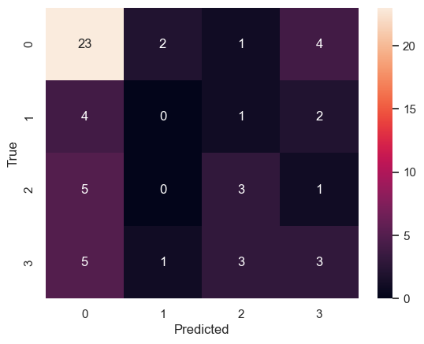

```python
from sklearn.metrics import confusion_matrix
import seaborn as sns
import matplotlib.pyplot as plt

cm = confusion_matrix(y_test, y_test_pred)

sns.heatmap(cm, annot=True, fmt='d')
plt.xlabel('Predicted')
plt.ylabel('True')
plt.show()
```

```python
# Predict probabilities on the testing set
y_test_pred_proba = clf_cv.predict_proba(X_test_processed)

# Compute AUC score on the testing set
test_auc = roc_auc_score(y_test, y_test_pred_proba, multi_class="ovr")

# Print AUC score on the testing set
print(f"Testing AUC: {test_auc}")
```

[output not shown]

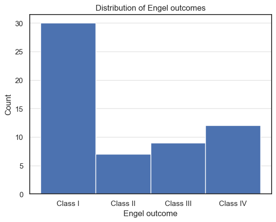

```python
# Create a histogram of the 'surg_engel' variable
plt.hist(y_test+1, bins=[1, 2, 3, 4, 5])  # Specify the bin edges

# Customize x-axis ticks and labels
bin_centers = [1.5, 2.5, 3.5, 4.5]
plt.xticks(bin_centers, ['Class I', 'Class II', 'Class III', 'Class IV'])

# Add labels and title
plt.xlabel('Engel outcome')
plt.ylabel('Count')
plt.title('Distribution of Engel outcomes')

# Add grid for better readability
plt.grid(axis='y', alpha=0.55)

# Show the plot
plt.show()
```

```python
from sklearn.metrics import classification_report

y_test_pred = clf_cv.predict(X_test_processed)

print(classification_report(y_test_pred, y_test))
```

[output not shown]

[figure not shown]

```python
from sklearn.metrics import confusion_matrix
import seaborn as sns
import matplotlib.pyplot as plt

cm = confusion_matrix(y_test, y_test_pred)

sns.heatmap(cm, annot=True, fmt='d')
plt.xlabel('Predicted')
plt.ylabel('True')
plt.show()
```

```python
from sklearn.metrics import classification_report

y_train_pred = clf_cv.predict(X_train_processed)

print(classification_report(y_train_pred, y_train))
```

[output not shown]

[figure not shown]

```python
from sklearn.metrics import confusion_matrix
import seaborn as sns
import matplotlib.pyplot as plt

cm = confusion_matrix(y_train, y_train_pred)

sns.heatmap(cm, annot=True, fmt='d')
plt.xlabel('Predicted')
plt.ylabel('True')
plt.show()
```

```python
import shap

# Update column names by removing "remainder__" and "pipeline__" prefixes
X_test_processed.columns = [col.replace("remainder__", "").replace("pipeline__", "") for col in X_test_processed.columns]


explainer = shap.TreeExplainer(clf_cv.best_estimator_)
shap_values = explainer.shap_values(X_test_processed)

shap.summary_plot(shap_values, X_test_processed, max_display=15)
```

```
IProgress not found. Please update jupyter and ipywidgets. See https://ipywidgets.readthedocs.io/en/stable/user_install.html
```

[output not shown]

```
Class 1
```

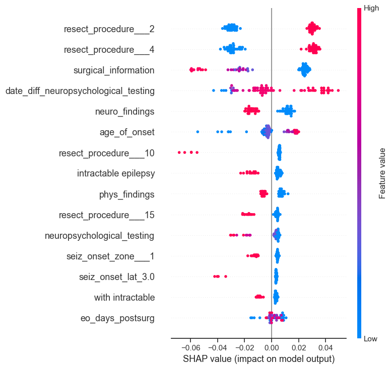

```
Class 2
```

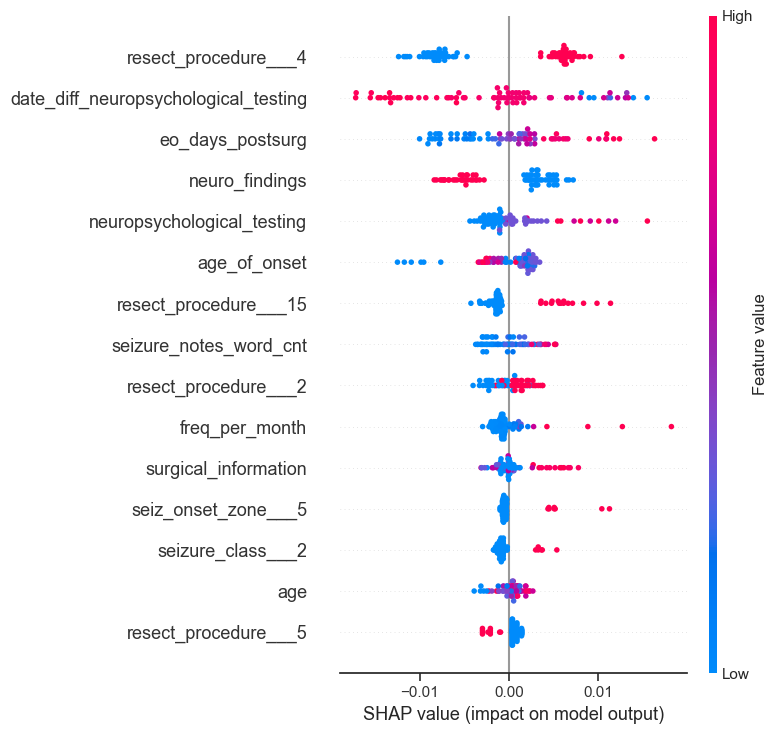

```
Class 3
```

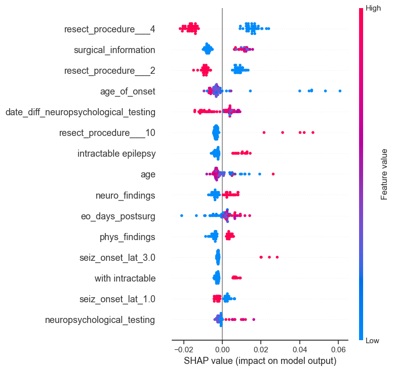

```
Class 4
```

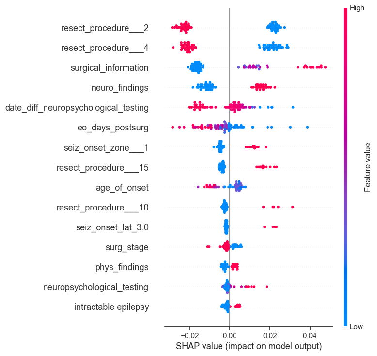

```python
import shap

# Update column names by removing "remainder__" and "pipeline__" prefixes
X_test_processed.columns = [col.replace("remainder__", "").replace("pipeline__", "") for col in X_test_processed.columns]


explainer = shap.TreeExplainer(clf_cv.best_estimator_)
shap_values = explainer.shap_values(X_test_processed)

for i in range(len(shap_values)):  # Iterate through each class if it's a multiclass classification
    print(f"Class {i+1}")  # Adjust class labeling to start from 1
    shap.summary_plot(shap_values[i], X_test_processed, max_display=15)
```

```python
# Print best parameters
for model in best_params:
    print(f"Best Parameters for {model}: {best_params[model]}")

print("\n")

# Print unique sorted values of best parameters
for model in best_params:
    print(f"Unique Sorted Values of Best Parameters for {model.capitalize()}:")

    # Gather all values for each parameter across best models
    all_params_values = {key: [] for key in models_and_parameters[model].keys()}
    for params in best_params[model]:
        for param, value in params.items():
            all_params_values[param].append(value)

    # Sort and remove duplicates from parameter values
    for param, values in all_params_values.items():
        unique_sorted_values = sorted(set(values))
        print(f"- {param}: {unique_sorted_values}")

    print("\n")
```

```
Best Parameters for logistic_regression: [{'model__C': 9.999999999999999e-05, 'model__l1_ratio': 0.0}, {'model__C': 9.999999999999999e-06, 'model__l1_ratio': 0.0}, {'model__C': 9.999999999999999e-06, 'model__l1_ratio': 0.0}, {'model__C': 0.01, 'model__l1_ratio': 0.0}, {'model__C': 0.01, 'model__l1_r…
Best Parameters for random_forest: [{'model__estimator__max_depth': 6, 'model__estimator__n_estimators': 70}, {'model__estimator__max_depth': 2, 'model__estimator__n_estimators': 103}, {'model__estimator__max_depth': 2, 'model__estimator__n_estimators': 37}, {'model__estimator__max_depth': 8, 'model…
Best Parameters for xgboost: [{'model__estimator__learning_rate': 0.09999999999999999, 'model__estimator__n_estimators': 70}, {'model__estimator__learning_rate': 0.09999999999999999, 'model__estimator__n_estimators': 37}, {'model__estimator__learning_rate': 0.0031622776601683794, 'model__estimator__…


Unique Sorted Values of Best Parameters for Logistic_regression:
- model__C: [9.999999999999999e-06, 9.999999999999999e-05, 0.001, 0.01]
- model__l1_ratio: [0.0]


Unique Sorted Values of Best Parameters for Random_forest:
- model__estimator__n_estimators: [5, 21, 37, 54, 70, 103]
- model__estimator__max_depth: [2, 4, 6, 8]


Unique Sorted Values of Best Parameters for Xgboost:
- model__estimator__n_estimators: [5, 37, 70, 103]
- model__estimator__learning_rate: [0.001, 0.0031622776601683794, 0.01, 0.09999999999999999]
```

## Scale continuous variables

```python
# Fit and transform on training and testing data
X_train_scaled = preprocessor.fit_transform(X_train)
X_test_scaled = preprocessor.transform(X_test)
```

## Null accuracy

```python
from sklearn.dummy import DummyClassifier
from sklearn.metrics import accuracy_score

# Create a DummyClassifier that always predicts the most frequent class
dummy_classifier = DummyClassifier(strategy='most_frequent')

# Fit the DummyClassifier on the training data
dummy_classifier.fit(X_train, y_train)

# Make predictions on the training data
y_pred_dummy = dummy_classifier.predict(X_test)

# Calculate null accuracy
null_accuracy = accuracy_score(y_test, y_pred_dummy)

print(f"Null Accuracy: {null_accuracy:.2f}")
```

```
Null Accuracy: 0.67
```

## ROC AND AUC

Here we calculate, the Weighted Average AUC Score:

This method computes the average of the metric weighted by the number of true instances for each class. It takes class imbalance into account, which is particularly useful if some classes are underrepresented in the data.

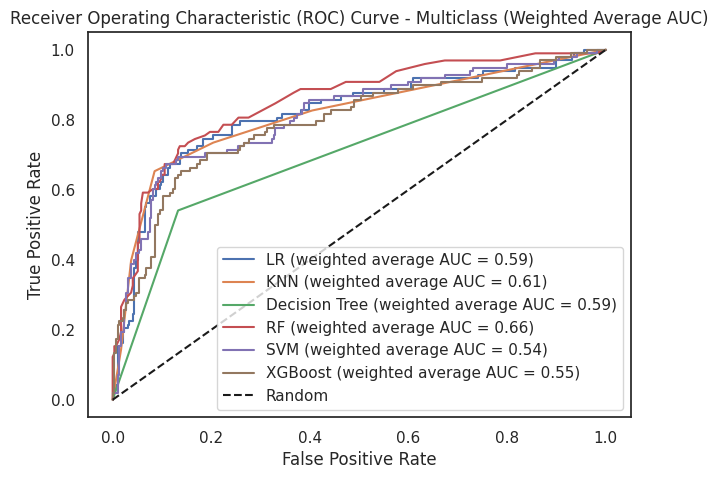

```python
import matplotlib.pyplot as plt
from sklearn.metrics import roc_auc_score, roc_curve
from sklearn.preprocessing import label_binarize
from sklearn.multiclass import OneVsRestClassifier
from sklearn.neighbors import KNeighborsClassifier
from sklearn.linear_model import LogisticRegression
from sklearn.tree import DecisionTreeClassifier
from sklearn.ensemble import RandomForestClassifier
from sklearn.svm import SVC
from xgboost import XGBClassifier
import numpy as np

# Assuming y_train and y_test are multiclass labels
n_classes = len(np.unique(y_train))
y_train_bin = label_binarize(y_train, classes=range(n_classes))
y_test_bin = label_binarize(y_test, classes=range(n_classes))

models = {
    #"Dummy": DummyClassifier(strategy='most_frequent'),
    "LR": LogisticRegression(max_iter=2000, random_state=42),
    "KNN": KNeighborsClassifier(),
    "Decision Tree": DecisionTreeClassifier(random_state=42),
    "RF": RandomForestClassifier(random_state=42),
    "SVM": SVC(max_iter=2000, probability=True, random_state=42),
    "XGBoost": XGBClassifier(random_state=42),
}

plt.figure(figsize=(7, 5))

for name, model in models.items():
    # Fit the model on the training data
    # Using OneVsRestClassifier for multiclass classification
    clf = OneVsRestClassifier(model)
    clf.fit(X_train_scaled, y_train_bin)

    # Predict probabilities
    y_pred_prob = clf.predict_proba(X_test_scaled)

    # Compute the weighted average ROC AUC score
    roc_auc_weighted = roc_auc_score(y_test_bin, y_pred_prob, average='weighted', multi_class='ovr')

    # Compute and plot ROC curve for each model
    fpr, tpr, _ = roc_curve(y_test_bin.ravel(), y_pred_prob.ravel())
    plt.plot(fpr, tpr, label=f"{name} (weighted average AUC = {roc_auc_weighted:.2f})")

plt.plot([0, 1], [0, 1], "k--", label="Random")
plt.xlabel("False Positive Rate")
plt.ylabel("True Positive Rate")
plt.title("Receiver Operating Characteristic (ROC) Curve - Multiclass (Weighted Average AUC)")
plt.legend(loc="lower right")
plt.show()
```

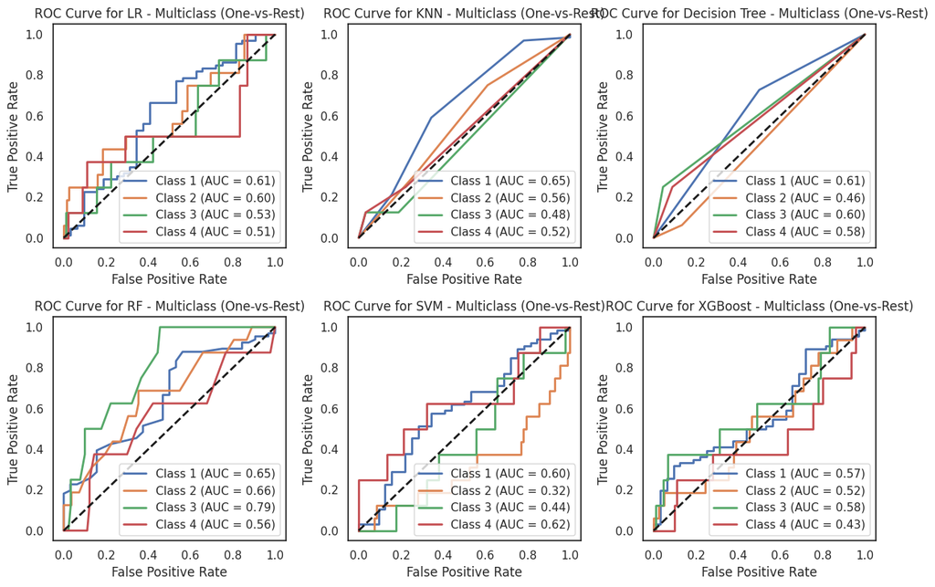

```python
import matplotlib.pyplot as plt
from sklearn.metrics import roc_auc_score, roc_curve
from sklearn.preprocessing import label_binarize
from sklearn.multiclass import OneVsRestClassifier
from sklearn.neighbors import KNeighborsClassifier
from sklearn.linear_model import LogisticRegression
from sklearn.tree import DecisionTreeClassifier
from sklearn.ensemble import RandomForestClassifier
from sklearn.svm import SVC
from xgboost import XGBClassifier
import numpy as np

# Assuming y_train and y_test are multiclass labels
n_classes = len(np.unique(y_train))
y_train_bin = label_binarize(y_train, classes=range(n_classes))
y_test_bin = label_binarize(y_test, classes=range(n_classes))

models = {
    "LR": LogisticRegression(max_iter=2000, random_state=42),
    "KNN": KNeighborsClassifier(),
    "Decision Tree": DecisionTreeClassifier(random_state=42),
    "RF": RandomForestClassifier(random_state=42),
    "SVM": SVC(max_iter=2000, probability=True, random_state=42),
    "XGBoost": XGBClassifier(random_state=42),
}

# Create a 2x3 subplot for different models
fig, axs = plt.subplots(2, 3, figsize=(12, 8))
model_keys = list(models.keys())

# Iterate over models and plot in subplots
for idx, (name, model) in enumerate(models.items()):
    ax = axs[idx // 3, idx % 3]

    clf = OneVsRestClassifier(model)
    clf.fit(X_train_scaled, y_train_bin)
    y_pred_prob = clf.predict_proba(X_test_scaled)

    for i in range(n_classes):
        fpr, tpr, _ = roc_curve(y_test_bin[:, i], y_pred_prob[:, i])
        roc_auc = roc_auc_score(y_test_bin[:, i], y_pred_prob[:, i])
        ax.plot(fpr, tpr, lw=2, label=f'Class {i + 1} (AUC = {roc_auc:.2f})')

    ax.plot([0, 1], [0, 1], 'k--', lw=2)
    ax.set_xlabel('False Positive Rate')
    ax.set_ylabel('True Positive Rate')
    ax.set_title(f'ROC Curve for {name} - Multiclass (One-vs-Rest)')
    ax.legend(loc='lower right')

# Adjust layout
plt.tight_layout()
plt.show()
```

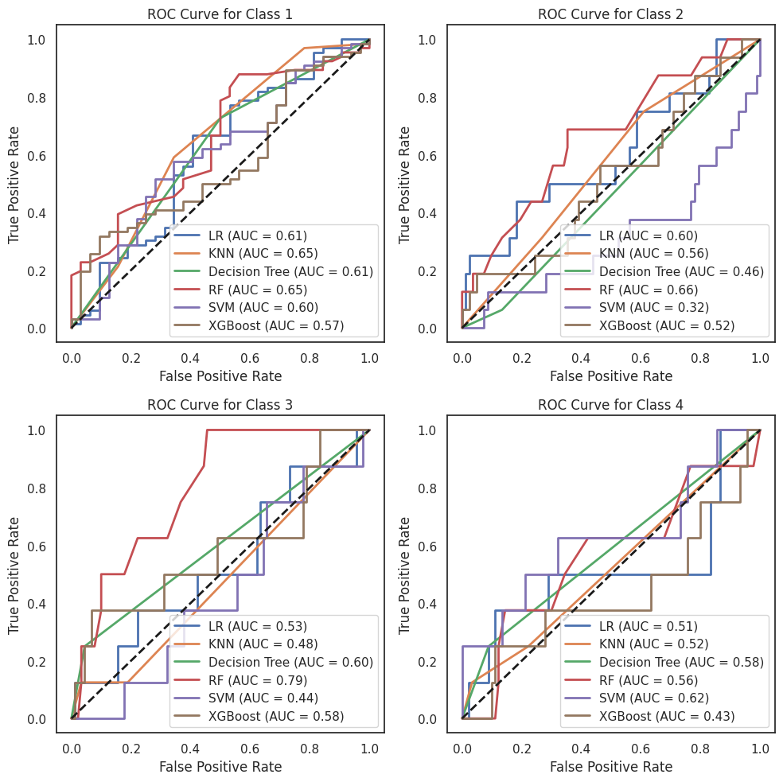

```python
# Pre-training models and storing predictions
model_predictions = {}
for name, model in models.items():
    clf = OneVsRestClassifier(model)
    clf.fit(X_train_scaled, y_train_bin)
    model_predictions[name] = clf.predict_proba(X_test_scaled)

# Creating 2x2 subplot for class-wise ROC curves
fig, axs = plt.subplots(2, 2, figsize=(10, 10))

for i in range(n_classes):
    ax = axs[i // 2, i % 2]

    for name in models.keys():
        y_pred_prob = model_predictions[name]

        fpr, tpr, _ = roc_curve(y_test_bin[:, i], y_pred_prob[:, i])
        roc_auc = roc_auc_score(y_test_bin[:, i], y_pred_prob[:, i])
        ax.plot(fpr, tpr, lw=2, label=f'{name} (AUC = {roc_auc:.2f})')

    ax.plot([0, 1], [0, 1], 'k--', lw=2)
    ax.set_xlabel('False Positive Rate')
    ax.set_ylabel('True Positive Rate')
    ax.set_title(f'ROC Curve for Class {i + 1}')
    ax.legend(loc='lower right')

plt.tight_layout()
plt.show()
```

## Logistic Regression

```python
from sklearn.linear_model import LogisticRegression
from sklearn.metrics import accuracy_score

# Create a Logistic Regression classifier for multiclass prediction
lr = LogisticRegression(max_iter=2000, random_state=42, multi_class='auto')

# Train the classifier on the training data
lr.fit(X_train_scaled, y_train)

# Make predictions on the test data
y_pred = lr.predict(X_test_scaled)

# Evaluate the accuracy of the model
accuracy = accuracy_score(y_test, y_pred)
print(f"Accuracy: {accuracy:.2f}")
```

```
Accuracy: 0.66
```

### Logistic Regression Coefficients

\begin{equation} P(Y=1) = \frac{1}{1 + e^{-(\beta_0 + \beta_1x_1 + \beta_2x_2 + \ldots + \beta_nx_n)}} \end{equation}

- Positive Coefficient: A positive coefficient for a feature means that an increase in that feature's value is associated with an increase in the log-odds of the response variable being in the positive class.
- Negative Coefficient: A negative coefficient for a feature means that an increase in that feature's value is associated with a decrease in the log-odds of the response variable being in the positive class.

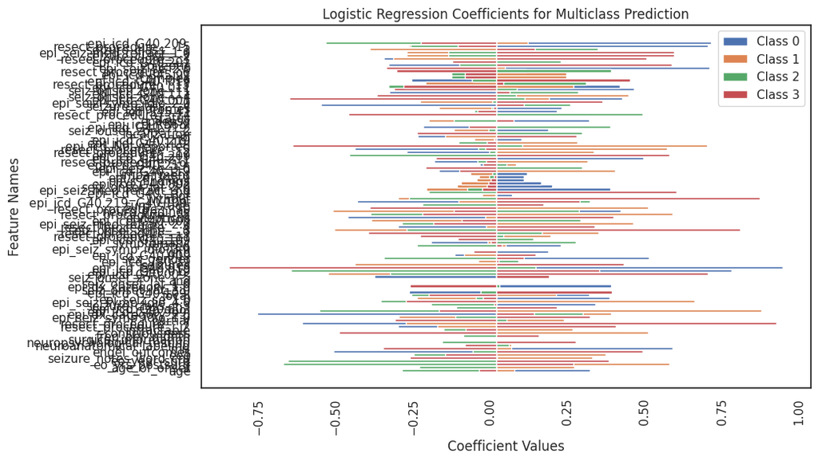

```python
import numpy as np
import matplotlib.pyplot as plt

# Get the coefficients and feature names
coefficients = lr.coef_  # This will give you coefficients for each class

# Create a bar plot for each class
plt.figure(figsize=(10, 6))
for class_label in range(len(coefficients)):
    plt.barh(column_names, coefficients[class_label], label=f'Class {class_label}')
plt.xlabel('Coefficient Values')
plt.ylabel('Feature Names')
plt.title('Logistic Regression Coefficients for Multiclass Prediction')
plt.xticks(rotation=90, ha="right")
plt.legend()
plt.show()
```

```python
# Get the intercept and coefficients
intercept = lr.intercept_[0]
coefficients = lr.coef_[0]

# Display the logistic regression equation
equation = f"P(Y=1) = 1 / (1 + e^(-({intercept:.4f} + "
for feature, coefficient in zip(numeric_var, coefficients):
    equation += f"{coefficient:.4f} * {feature} + "
equation = equation[:-2]  # Remove the trailing ' + '
equation += ")))"

print("Logistic Regression Equation:")
print(equation)
```

```
Logistic Regression Equation:
P(Y=1) = 1 / (1 + e^(-(1.8718 + 0.3033 * age + -0.0017 * age_of_onset + -0.1201 * eo_yrs_postsurg + 0.0039 * eo_year_surg + -0.0329 * seizure_notes_word_cnt + 0.0779 * eeg + -0.5278 * engel_outcomes + 0.5691 * mri + 0.0129 * neuroanatomical_labeling + -0.0448 * neuropsychological_testing + 0.0000 * …
```

## Decision Tree classifier

```python
from sklearn.tree import DecisionTreeClassifier
from sklearn.metrics import accuracy_score

# Create a Decision Tree Classifier for multiclass prediction
clf = DecisionTreeClassifier(max_depth=3, random_state=42)

# Train the classifier on the training data
clf.fit(X_train, y_train)

# Make predictions on the test data
y_pred = clf.predict(X_test)

# Evaluate the accuracy of the model
accuracy = accuracy_score(y_test, y_pred)
print(f"Accuracy: {accuracy:.2f}")
```

```
Accuracy: 0.67
```

```python
from sklearn.tree import DecisionTreeClassifier
from sklearn.model_selection import RandomizedSearchCV
from sklearn.metrics import accuracy_score, precision_score, recall_score, f1_score

# Define the parameter grid
param_grid = {
    'max_depth': [3, 5, 10, None],
    'min_samples_split': [2, 5, 10],
    'min_samples_leaf': [1, 2, 4],
    'criterion': ['gini', 'entropy']
}

# Create a Decision Tree Classifier
clf = DecisionTreeClassifier(random_state=42)

# Create the RandomizedSearchCV object
random_search = RandomizedSearchCV(clf, param_distributions=param_grid, n_iter=100, cv=5, verbose=1, random_state=42)

# Fit the model
random_search.fit(X_train, y_train)

# Print the best parameters
print("Best parameters:", random_search.best_params_)

# Use the best model to make predictions
best_clf = random_search.best_estimator_
y_pred = best_clf.predict(X_test)

# Evaluate the accuracy, precision, recall, and F1-score of the model
accuracy = accuracy_score(y_test, y_pred)
precision = precision_score(y_test, y_pred, average='weighted')
recall = recall_score(y_test, y_pred, average='weighted')
f1 = f1_score(y_test, y_pred, average='weighted')

print(f"Accuracy: {accuracy:.2f}")
print(f"Precision: {precision:.2f}")
print(f"Recall: {recall:.2f}")
print(f"F1-Score: {f1:.2f}")
```

```
Fitting 5 folds for each of 72 candidates, totalling 360 fits
```

```
Best parameters: {'min_samples_split': 2, 'min_samples_leaf': 1, 'max_depth': 3, 'criterion': 'entropy'}
Accuracy: 0.66
Precision: 0.45
Recall: 0.66
F1-Score: 0.54
```

### Plot decision tree

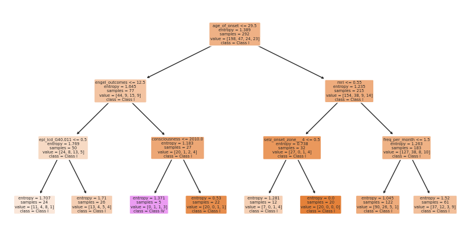

```python
from sklearn.tree import plot_tree

# Define class names for your specific problem (modify as needed)
class_names = ["Class I", "Class II", "Class III", "Class IV"]

# Plot the decision tree
plt.figure(figsize=(10, 5))
plot_tree(best_clf, filled=True, feature_names=column_names, class_names=class_names, rounded=True)
plt.show()
```

## Random Forest

```python
from sklearn.ensemble import RandomForestClassifier
from sklearn.metrics import accuracy_score

# Create a Random Forest classifier
rf = RandomForestClassifier(n_estimators=100, random_state=42)

# Train the classifier on the training data
rf.fit(X_train_scaled, y_train)

# Make predictions on the test data
y_pred = rf.predict(X_test_scaled)

# Evaluate the accuracy of the model
accuracy = accuracy_score(y_test, y_pred)
print(f"Accuracy: {accuracy:.2f}")
```

```
Accuracy: 0.67
```

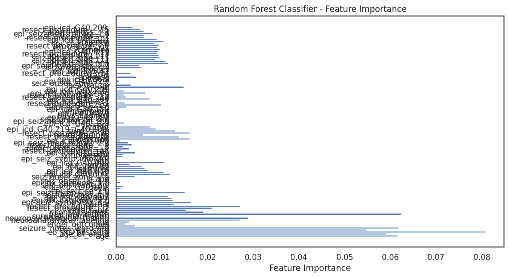

```python
# Get feature importances from the trained Random Forest model
feature_importances = rf.feature_importances_

# Create a bar plot of feature importances
plt.figure(figsize=(10, 6))
plt.barh(range(len(feature_importances)), feature_importances, align="center")
plt.yticks(range(len(feature_importances)), column_names)
plt.xlabel("Feature Importance")
plt.title("Random Forest Classifier - Feature Importance")
plt.show()
```

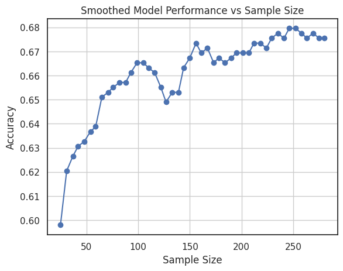

```python
# Create a Random Forest classifier
rf = RandomForestClassifier(n_estimators=100, random_state=42)

# Lists to store the results
sample_sizes = []
accuracies = []

# Loop over different sample sizes
for fraction in np.linspace(0.05, 1.0, 50):
    # Determine the sample size
    sample_size = int(fraction * X_train_scaled.shape[0])
    sample_sizes.append(sample_size)

    # Sample the training data
    X_train_sampled = X_train_scaled[:sample_size]
    y_train_sampled = y_train[:sample_size]

    # Train the classifier on the sampled training data
    rf.fit(X_train_sampled, y_train_sampled)

    # Make predictions on the test data
    y_pred = rf.predict(X_test_scaled)

    # Evaluate the accuracy of the model
    accuracy = accuracy_score(y_test, y_pred)
    accuracies.append(accuracy)

# Applying a simple moving average for smoothing
window_size = 5
smoothed_accuracies = np.convolve(accuracies, np.ones(window_size)/window_size, mode='valid')

# Plotting
plt.plot(sample_sizes[int(window_size/2):-int(window_size/2)], smoothed_accuracies, marker='o')
plt.xlabel('Sample Size')
plt.ylabel('Accuracy')
plt.title('Smoothed Model Performance vs Sample Size')
plt.grid(True)
plt.show()
```

## Support Vector Machines (SVM)

```python
from sklearn.svm import SVC
from sklearn.metrics import accuracy_score

# Create an SVM classifier
svc = SVC(kernel='linear', C=1, random_state=42)

# Train the classifier on the training data
svc.fit(X_train_scaled, y_train)

# Make predictions on the test data
y_pred = svc.predict(X_test_scaled)

# Evaluate the accuracy of the model
accuracy = accuracy_score(y_test, y_pred)
print(f"Accuracy: {accuracy:.2f}")
```

```
Accuracy: 0.66
```

## XGBoost

```python
from xgboost import XGBClassifier
from sklearn.metrics import accuracy_score

# Create an XGBoost classifier for multiclass prediction
xgb = XGBClassifier(objective='multi:softmax', random_state=42)

# Train the classifier on the training data
xgb.fit(X_train_scaled, y_train)

# Make predictions on the test data
y_pred = xgb.predict(X_test_scaled)

# Evaluate the accuracy of the model
accuracy = accuracy_score(y_test, y_pred)
print(f"Accuracy: {accuracy:.2f}")
```

```
Accuracy: 0.62
```

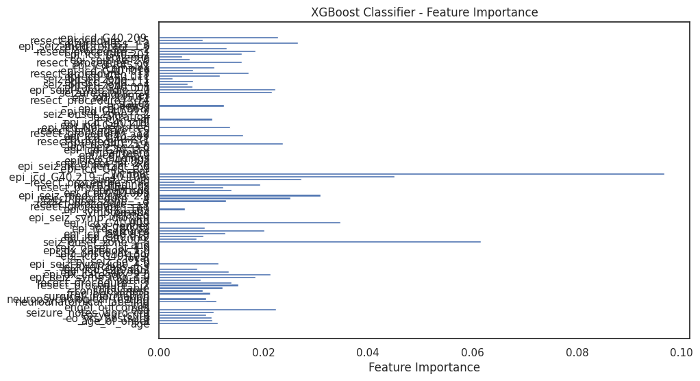

```python
# Get feature importances from the trained XGBoost model
feature_importances = xgb.feature_importances_

# Create a bar plot of feature importances
plt.figure(figsize=(10, 6))
plt.barh(range(len(feature_importances)), feature_importances, align="center")
plt.yticks(range(len(feature_importances)), column_names)
plt.xlabel("Feature Importance")
plt.title("XGBoost Classifier - Feature Importance")
plt.show()
```

## Neural Network

```python
import tensorflow as tf

# Create a simple neural network model using Keras
model = tf.keras.Sequential([
    tf.keras.layers.Dense(32, activation='relu', input_shape=(X_train.shape[1],)),
    tf.keras.layers.Dense(32, activation='relu'),
    tf.keras.layers.Dense(32, activation='relu'),
    tf.keras.layers.Dense(32, activation='relu'),
    tf.keras.layers.Dense(32, activation='relu'),
    tf.keras.layers.Dense(32, activation='relu'),
    tf.keras.layers.Dense(len(set(y_train)), activation='softmax')  # Output layer for multiclass classification
])

# Compile the model
model.compile(optimizer='adam', loss='sparse_categorical_crossentropy', metrics=['accuracy'])

# Train the model on the training data
model.fit(X_train_scaled, y_train, epochs=15, batch_size=64, validation_split=0.2, verbose=2)

# Make predictions on the test data
y_pred_prob = model.predict(X_test_scaled)
y_pred = tf.argmax(y_pred_prob, axis=1).numpy()

# Evaluate the accuracy of the model
accuracy = accuracy_score(y_test, y_pred)
print(f"Accuracy: {accuracy:.2f}")
```

```
4/4 - 1s - loss: 1.4020 - accuracy: 0.1330 - val_loss: 1.3362 - val_accuracy: 0.2881 - 1s/epoch - 311ms/step
4/4 - 0s - loss: 1.3208 - accuracy: 0.4506 - val_loss: 1.2503 - val_accuracy: 0.8136 - 45ms/epoch - 11ms/step
4/4 - 0s - loss: 1.2482 - accuracy: 0.6481 - val_loss: 1.1506 - val_accuracy: 0.8136 - 44ms/epoch - 11ms/step
4/4 - 0s - loss: 1.1698 - accuracy: 0.6438 - val_loss: 1.0287 - val_accuracy: 0.8136 - 43ms/epoch - 11ms/step
4/4 - 0s - loss: 1.0904 - accuracy: 0.6438 - val_loss: 0.9039 - val_accuracy: 0.8136 - 42ms/epoch - 11ms/step
4/4 - 0s - loss: 1.0431 - accuracy: 0.6438 - val_loss: 0.8164 - val_accuracy: 0.8136 - 53ms/epoch - 13ms/step
4/4 - 0s - loss: 1.0285 - accuracy: 0.6438 - val_loss: 0.7876 - val_accuracy: 0.8136 - 51ms/epoch - 13ms/step
4/4 - 0s - loss: 1.0209 - accuracy: 0.6438 - val_loss: 0.7853 - val_accuracy: 0.8136 - 42ms/epoch - 10ms/step
4/4 - 0s - loss: 1.0048 - accuracy: 0.6438 - val_loss: 0.7912 - val_accuracy: 0.8136 - 44ms/epoch - 11ms/step
4/4 - 0s - loss: 0.9921 - accuracy: 0.6438 - val_loss: 0.8008 - val_accuracy: 0.8136 - 41ms/epoch - 10ms/step
4/4 - 0s - loss: 0.9864 - accuracy: 0.6438 - val_loss: 0.8171 - val_accuracy: 0.8136 - 42ms/epoch - 11ms/step
4/4 - 0s - loss: 0.9796 - accuracy: 0.6438 - val_loss: 0.8125 - val_accuracy: 0.8136 - 43ms/epoch - 11ms/step
4/4 - 0s - loss: 0.9704 - accuracy: 0.6438 - val_loss: 0.7940 - val_accuracy: 0.8136 - 42ms/epoch - 11ms/step
4/4 - 0s - loss: 0.9607 - accuracy: 0.6438 - val_loss: 0.7758 - val_accuracy: 0.8136 - 49ms/epoch - 12ms/step
4/4 - 0s - loss: 0.9551 - accuracy: 0.6438 - val_loss: 0.7637 - val_accuracy: 0.8136 - 43ms/epoch - 11ms/step
Accuracy: 0.67
```

## Perform PCA

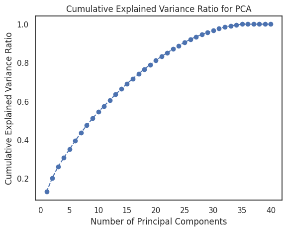

```python
import pandas as pd
from sklearn.decomposition import PCA
from sklearn.impute import SimpleImputer
from sklearn.preprocessing import StandardScaler
import matplotlib.pyplot as plt

# Extract numerical features
numerical_features = X.select_dtypes(include=['float64', 'int64']).copy()

# Impute missing values
imputer = SimpleImputer(strategy='mean')  # You can use other strategies like 'median' or 'most_frequent'
numerical_features_imputed = pd.DataFrame(imputer.fit_transform(numerical_features), columns=numerical_features.columns)

# Data preprocessing (standardization)
scaler = StandardScaler()
numerical_features_scaled = scaler.fit_transform(numerical_features_imputed)

# Perform PCA
pca = PCA()
pca_result = pca.fit_transform(numerical_features_scaled)

# Plot explained variance ratio
explained_variance_ratio = pca.explained_variance_ratio_
cumulative_variance_ratio = explained_variance_ratio.cumsum()

plt.plot(range(1, len(explained_variance_ratio) + 1), cumulative_variance_ratio, marker='o', linestyle='--')
plt.xlabel('Number of Principal Components')
plt.ylabel('Cumulative Explained Variance Ratio')
plt.title('Cumulative Explained Variance Ratio for PCA')
plt.show()
```

```python
from sklearn.decomposition import PCA
from sklearn.impute import SimpleImputer
from sklearn.model_selection import train_test_split
from sklearn.metrics import accuracy_score
from sklearn.preprocessing import StandardScaler

X2 = wide_df.drop(["surg_engel", "surg_engel___1", "surg_engel___2", "surg_engel___3",
                   "surg_engel___4", "engel_class1", "engel_class2", "engel_class3",
                   "engel_class4",], axis=1)
# Extract numerical features
numerical_features = X.select_dtypes(include=['float64', 'int64']).copy()

# Split the data into training and testing sets
X_train, X_test, y_train, y_test = train_test_split(numerical_features, y, test_size=0.2, random_state=42)

# Impute missing values separately for training and testing sets
imputer = SimpleImputer(strategy='mean')
X_train_imputed = pd.DataFrame(imputer.fit_transform(X_train), columns=X_train.columns)
X_test_imputed = pd.DataFrame(imputer.transform(X_test), columns=X_test.columns)

# Data preprocessing (standardization)
scaler = StandardScaler()
X_train_scaled = scaler.fit_transform(X_train_imputed)
X_test_scaled = scaler.transform(X_test_imputed)

# Perform PCA
pca = PCA(n_components=20)  # Choose the number of components based on your analysis
pca_result_train = pca.fit_transform(X_train_scaled)
pca_result_test = pca.transform(X_test_scaled)

# Create a Support Vector Machine
svc = SVC(kernel='linear', C=1.0, random_state=42)

# Train the classifier on the training data
svc.fit(pca_result_train, y_train)

# Make predictions on the test data
y_pred = svc.predict(pca_result_test)

# Evaluate the accuracy of the model
accuracy = accuracy_score(y_test, y_pred)
print(f"Accuracy: {accuracy:.2f}")
```

```
Accuracy: 0.62
```

```python
from imblearn.over_sampling import SMOTE
from sklearn.utils.class_weight import compute_class_weight
from tensorflow.keras.models import Sequential
from tensorflow.keras.layers import Dense, Dropout

# Separate features and target
X = wide_df.drop(["surg_engel", "surg_engel___1", "surg_engel___2", "surg_engel___3",
                   "surg_engel___4", "engel_class1", "engel_class2", "engel_class3",
                   "engel_class4",], axis=1)
#y = wide_df[["surg_engel___1", "surg_engel___2", "surg_engel___3", "surg_engel___4"]]
y = wide_df["surg_engel"]

# Extract numerical features
numerical_features = X.select_dtypes(include=['float64', 'int64']).copy()

# Split the data into training and testing sets
X_train, X_test, y_train, y_test = train_test_split(numerical_features, y, test_size=0.2, random_state=42)

# Impute missing values separately for training and testing sets
imputer = SimpleImputer(strategy='median')
X_train_imputed = pd.DataFrame(imputer.fit_transform(X_train), columns=X_train.columns)
X_test_imputed = pd.DataFrame(imputer.transform(X_test), columns=X_test.columns)

# Now apply SMOTE
#smote = SMOTE()
#X_train, y_train = smote.fit_resample(X_train_imputed, y_train)

# Calculate class weights
#class_weights = compute_class_weight('balanced', classes=np.unique(y_train), y=y_train)
#class_weight_dict = dict(enumerate(class_weights))

y_train = pd.get_dummies(y_train)
y_test = pd.get_dummies(y_test)

# Data preprocessing (standardization)
#scaler = StandardScaler()
#X_train = scaler.fit_transform(X_train_imputed)
#X_test = scaler.transform(X_test_imputed)


model = Sequential()
model.add(Dense(700, activation='relu', input_shape=(X_train_imputed.shape[1],)))
model.add(Dropout(0.5))
model.add(Dense(350, activation='relu'))
model.add(Dropout(0.5))
model.add(Dense(150, activation='relu'))
model.add(Dense(len(set(y_train)), activation='softmax'))  # Adjust according to your output classes

model.compile(optimizer='adam', loss='categorical_crossentropy', metrics=['accuracy'])

# Train the model on the training data
history = model.fit(X_train_imputed, y_train, epochs=50, batch_size=64, validation_split=0.2, verbose=2) # class_weight=class_weight_dict

# Evaluate the accuracy of the model
loss, accuracy = model.evaluate(X_test_imputed, y_test)

# Predict probabilities on the test set
y_pred_prob = model.predict(X_test_imputed)

# Calculate AUC for each class and average them
auc_scores = roc_auc_score(y_test, y_pred_prob, multi_class="ovr", average="weighted")

print(f"Test Accuracy: {accuracy*100:.2f}%")
print(f"Average AUC: {auc_scores:.2f}")
```

[output not shown]

[output not shown]

[figure not shown]

```python
import matplotlib.pyplot as plt

# Extracting loss and accuracy from the history object
training_loss = history.history['loss']
validation_loss = history.history['val_loss']
epochs = range(1, len(training_loss) + 1)

# Plotting Training and Validation Loss
plt.figure(figsize=(12, 5))

# Training vs Validation Loss
plt.plot(epochs, training_loss, 'bo-', label='Training Loss')
plt.plot(epochs, validation_loss, 'ro-', label='Validation Loss')
plt.title('Training and Validation Loss')
plt.xlabel('Epochs')
plt.ylabel('Loss')
plt.legend()

plt.show()
```

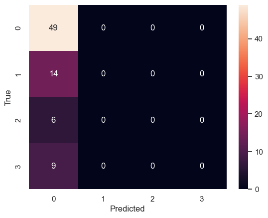

```python
from sklearn.metrics import confusion_matrix
import seaborn as sns
import matplotlib.pyplot as plt

# Assuming you have a trained model and test data
y_pred = model.predict(X_test)
y_test_labels = np.argmax(y_test, axis=1)  # If y_test is one-hot encoded
y_pred_labels = np.argmax(y_pred, axis=1)

cm = confusion_matrix(y_test_labels, y_pred_labels)

sns.heatmap(cm, annot=True, fmt='d')
plt.xlabel('Predicted')
plt.ylabel('True')
plt.show()
```

```python
from tensorflow.keras.models import Sequential
from tensorflow.keras.layers import Dense, Dropout

# Separate features and target
X = wide_df.drop(["surg_engel", "surg_engel___1", "surg_engel___2", "surg_engel___3",
                   "surg_engel___4", "engel_class1", "engel_class2", "engel_class3",
                   "engel_class4",], axis=1)
y = wide_df["surg_engel"] - 1

# Extract numerical features
numerical_features = X.select_dtypes(include=['float64', 'int64']).copy()

# Split the data into training and testing sets
X_train, X_test, y_train, y_test = train_test_split(numerical_features, y, test_size=0.2, random_state=42)

# Impute missing values separately for training and testing sets
imputer = SimpleImputer(strategy='median')
X_train_imputed = pd.DataFrame(imputer.fit_transform(X_train), columns=X_train.columns)
X_test_imputed = pd.DataFrame(imputer.transform(X_test), columns=X_test.columns)

# Data preprocessing (standardization)
#scaler = StandardScaler()
#X_train = scaler.fit_transform(X_train_imputed)
#X_test = scaler.transform(X_test_imputed)

# Define a range of hyperparameters for randomized search
param_distributions = {
    'n_estimators': [300, 400, 500],
    'learning_rate': [0.005, 0.01, 0.05],
    'max_depth': [4, 5, 6],
    'subsample': [0.4, 0.5, 0.6],
    'colsample_bytree': [0.5, 0.6, 0.7]
}

# Initialize the XGBClassifier
xgb_model = XGBClassifier()

# Set up RandomizedSearchCV
random_search = RandomizedSearchCV(estimator=xgb_model, param_distributions=param_distributions,
                                   n_iter=100, cv=5, verbose=2, random_state=42, n_jobs=-1)

# Fit the random search to the data
random_search.fit(X_train_imputed, y_train)

# Print the best parameters and best score
print(f"Best Parameters: {random_search.best_params_}")
print(f"Best Score: {random_search.best_score_}")

# Evaluate the best model on the test set
best_model = random_search.best_estimator_
accuracy = best_model.score(X_test_imputed, y_test)
print(f"Test Accuracy: {accuracy*100:.2f}%")
```

```
Fitting 5 folds for each of 100 candidates, totalling 500 fits
Best Parameters: {'subsample': 0.4, 'n_estimators': 500, 'max_depth': 5, 'learning_rate': 0.01, 'colsample_bytree': 0.5}
Best Score: 0.6859703020993344
Test Accuracy: 62.82%
```

## Print system information

```python
import session_info

session_info.show()
```

[output not shown]